# AID Clase 3

Cecilia Oliva

15/04/2023

# Tests de Independencia y Homogeneidad

## Test de Independencia

Supongamos que queremos saber si existe relación entre el estado civil de un grupo de personas, y su nivel de stress.

H0: el estado civil es independiente del nivel de stress (para todo i y j $P(X=x_i,Y=y_j)=P(X=x_i).P(Y=y_j)$ i= 1, 2, 3; j= 1, 2).

H1: las variables no son independientes (existe al menos algún par i y j tal que $P(X=x_i,Y=y_j)\neq P(X=x_i).P(Y=y_j)$ i= 1, 2, 3; j= 1, 2).

Contamos con los datos de la siguiente tabla:

```r
CantStressBajo<-c(155,204,103)
CantStressAlto<-c(100,122,183)
Tab<-as.table(rbind(CantStressBajo,CantStressAlto))
dimnames(Tab)<-list(Stress=c("Bajo","Alto"),EstadoCivil=c("Soltero","Casado","Divorciado"))
Tab
```

```
##       EstadoCivil
## Stress Soltero Casado Divorciado
##   Bajo     155    204        103
##   Alto     100    122        183
```

### Gráficos útiles

#### Gráfico de barras adyacentes

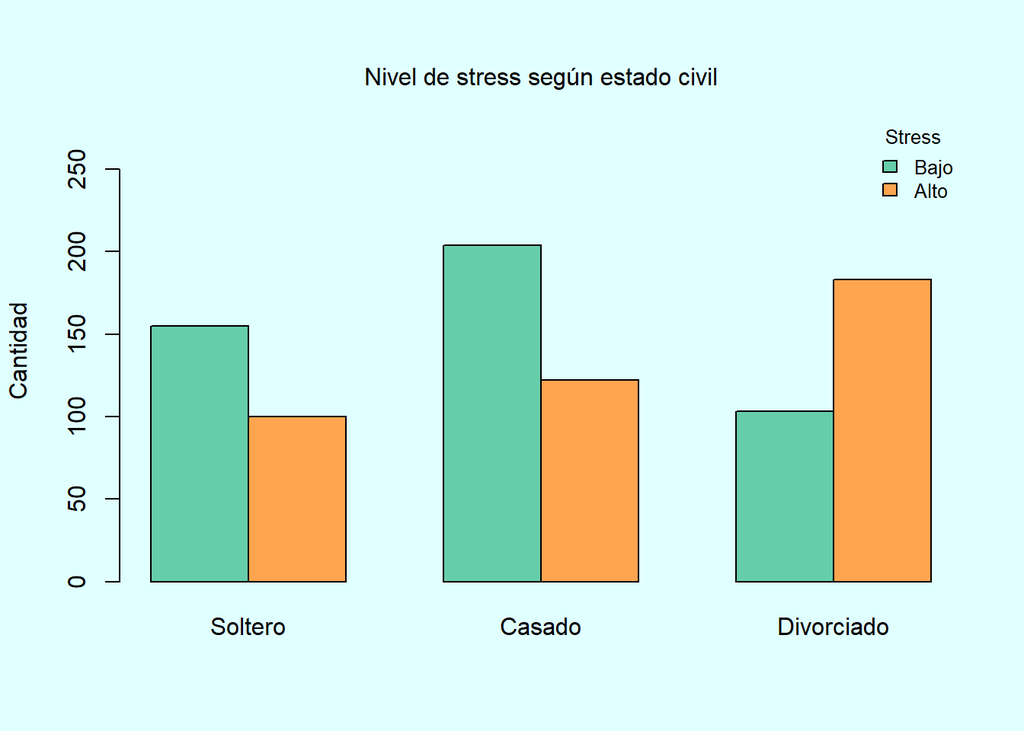

```r
par(bg="lightcyan")
barplot(Tab,beside=TRUE,col= c("aquamarine3","tan1"),ylim=c(0,280),ylab="Cantidad")
#title("Nivel de stress según estado civil",cex=0.75)
mtext("Nivel de stress según estado civil",cex=1,line=1)
legend("topright",cex=0.8,title="Stress",c("Bajo","Alto"), fill=c("aquamarine3","tan1"),horiz=F, box.lty = 0)
```

#### Gráfico de mosaicos

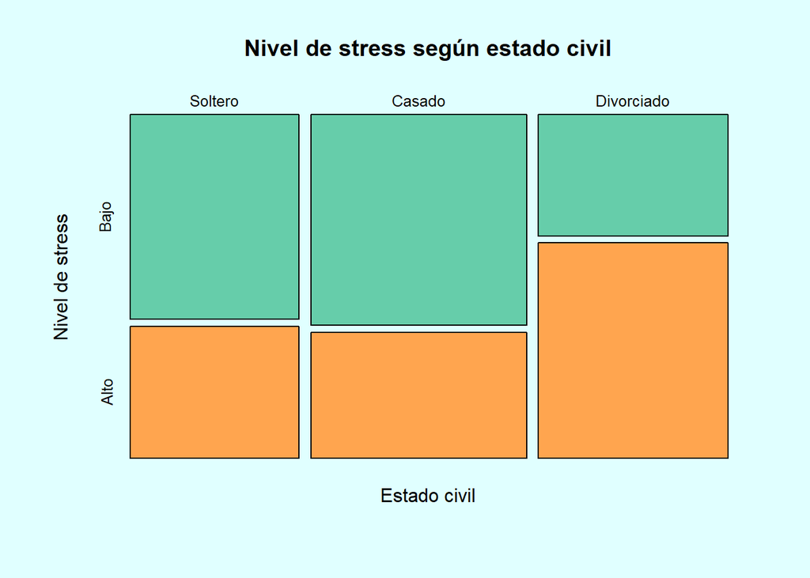

```r
par(bg="lightcyan")
mosaicplot(t(Tab),col=c("aquamarine3","tan1"),main="Nivel de stress según estado civil",ylab="Nivel de stress",xlab="Estado civil",
           cex=0.8)
```

Aplicación del test Chi-cuadrado:

```r
chisq.test(Tab)
```

```
##
##  Pearson's Chi-squared test
##
## data:  Tab
## X-squared = 51.341, df = 2, p-value = 7.104e-12
```

Analizamos las subtablas de contingencia:

```r
Tab1<-Tab[,-1]
chisq.test(Tab1)
```

```
##
##  Pearson's Chi-squared test with Yates' continuity correction
##
## data:  Tab1
## X-squared = 41.941, df = 1, p-value = 9.405e-11
```

```r
Tab2<-Tab[,-2]
chisq.test(Tab2)
```

```
##
##  Pearson's Chi-squared test with Yates' continuity correction
##
## data:  Tab2
## X-squared = 32.17, df = 1, p-value = 1.412e-08
```

```r
Tab3<-Tab[,-3]
chisq.test(Tab3)
```

```
##
##  Pearson's Chi-squared test with Yates' continuity correction
##
## data:  Tab3
## X-squared = 0.12617, df = 1, p-value = 0.7224
```

Veamos algunos outputs que devuelve el comando chisq.test:

```r
names(chisq.test(Tab))
```

```
## [1] "statistic" "parameter" "p.value"   "method"    "data.name" "observed"
## [7] "expected"  "residuals" "stdres"
```

```r
chisq.test(Tab)$statistic
```

```
## X-squared
##  51.34064
```

```r
chisq.test(Tab)$expected
```

```
##       EstadoCivil
## Stress  Soltero   Casado Divorciado
##   Bajo 135.8824 173.7163   152.4014
##   Alto 119.1176 152.2837   133.5986
```

```r
chisq.test(Tab)$residuals
```

```
##       EstadoCivil
## Stress   Soltero    Casado Divorciado
##   Bajo  1.640034  2.297678  -4.001701
##   Alto -1.751646 -2.454046   4.274036
```

```r
chisq.test(Tab)$stdres
```

```
##       EstadoCivil
## Stress  Soltero   Casado Divorciado
##   Bajo  2.85607  4.25581   -7.15234
##   Alto -2.85607 -4.25581    7.15234
```

```r
chisq.test(Tab1)$statistic
```

```
## X-squared
##  41.94136
```

```r
chisq.test(Tab1)$expected
```

```
##       EstadoCivil
## Stress   Casado Divorciado
##   Bajo 163.5327   143.4673
##   Alto 162.4673   142.5327
```

```r
chisq.test(Tab1)$residuals
```

```
##       EstadoCivil
## Stress    Casado Divorciado
##   Bajo  3.164479  -3.378531
##   Alto -3.174837   3.389590
```

```r
chisq.test(Tab1)$stdres
```

```
##       EstadoCivil
## Stress    Casado Divorciado
##   Bajo  6.557234  -6.557234
##   Alto -6.557234   6.557234
```

```r
chisq.test(Tab2)$statistic
```

```
## X-squared
##   32.1704
```

```r
chisq.test(Tab2)$expected
```

```
##       EstadoCivil
## Stress  Soltero Divorciado
##   Bajo 121.6081   136.3919
##   Alto 133.3919   149.6081
```

```r
chisq.test(Tab2)$residuals
```

```
##       EstadoCivil
## Stress   Soltero Divorciado
##   Bajo  3.028025  -2.859213
##   Alto -2.891186   2.730003
```

```r
chisq.test(Tab2)$stdres
```

```
##       EstadoCivil
## Stress   Soltero Divorciado
##   Bajo  5.758116  -5.758116
##   Alto -5.758116   5.758116
```

```r
chisq.test(Tab3)$statistic
```

```
## X-squared
## 0.1261745
```

```r
chisq.test(Tab3)$expected
```

```
##       EstadoCivil
## Stress   Soltero   Casado
##   Bajo 157.56454 201.4355
##   Alto  97.43546 124.5645
```

```r
chisq.test(Tab3)$residuals
```

```
##       EstadoCivil
## Stress    Soltero     Casado
##   Bajo -0.2043059  0.1806934
##   Alto  0.2598075 -0.2297804
```

```r
chisq.test(Tab3)$stdres
```

```
##       EstadoCivil
## Stress    Soltero     Casado
##   Bajo -0.4412368  0.4412368
##   Alto  0.4412368 -0.4412368
```

## Test de homogeneidad

Supongamos que queremos saber si existe diferencia entre el color de cabello de tres poblaciones pertenecientes a tres ciudades respectivamente. Contamos con los datos de la siguiente tabla:

H0: el color de cabello es homogéneo en las tres poblaciones/ciudades (para todo i y j $P(X=x_i|Y=Pob_j)=P(X=x_i)$ i= 1, 2; j= 1, 2, 3).

H1: el color de cabello no es homogéneo en todas las poblaciones (exite al menos algún par i y j tal que $P(X=x_i|Y=Pob_j)\neq P(X=x_i)$ i= 1, 2; j= 1, 2, 3).

Contamos con los datos de la siguiente tabla:

```r
Pob1<-c(99,53)#Ciudad Norte
Pob2<-c(105,65)#Ciudad Centro
Pob3<-c(150,48)#Ciudad Sur

TabPob<-as.table(rbind(Pob1,Pob2,Pob3))
dimnames(TabPob)<-list(Ciudad=c("Norte","Centro","Sur"),ColorPelo=c("Rubios","Morochos"))
TabPob
```

```
##         ColorPelo
## Ciudad   Rubios Morochos
##   Norte      99       53
##   Centro    105       65
##   Sur       150       48
```

### Gráficos útiles

#### Gráfico de barras adyacentes

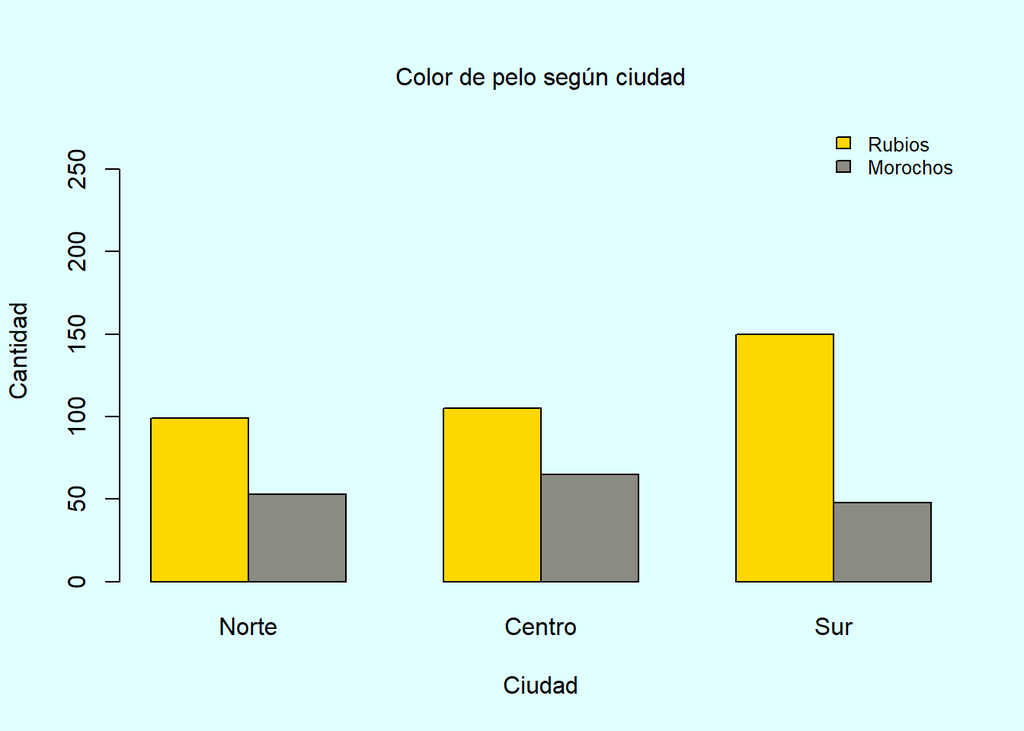

```r
par(bg="lightcyan")
barplot(t(TabPob),beside=TRUE,col= c("gold","ivory4"),ylim=c(0,280),ylab="Cantidad",xlab="Ciudad")
mtext("Color de pelo según ciudad",cex=1,line=1)
legend("topright",cex=0.8,c("Rubios","Morochos"), fill=c("gold","ivory4"),horiz=F, box.lty = 0)
```

#### Gráfico de mosaicos

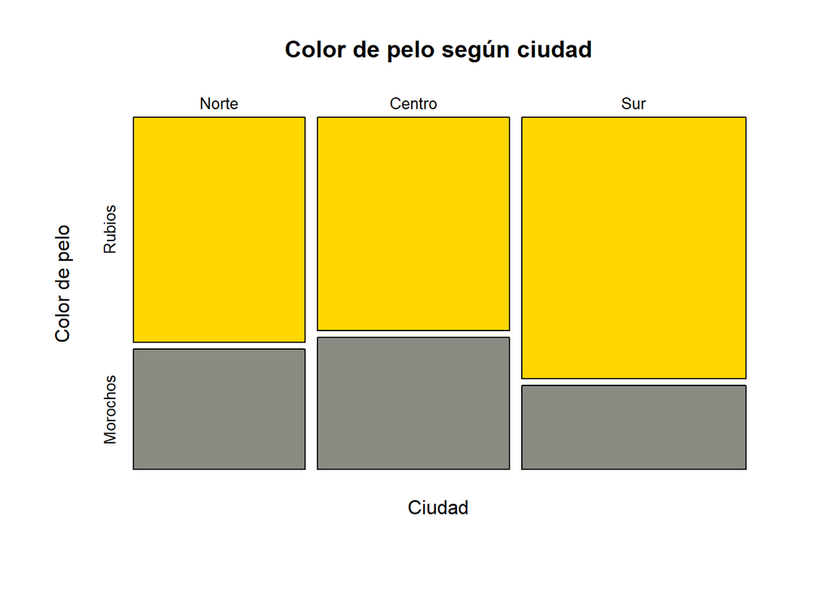

```r
mosaicplot(TabPob,col=c("gold","ivory4"),main="Color de pelo según ciudad",ylab="Color de pelo",xlab="Ciudad",cex=0.8)
```

#### Aplicación del test Chi-cuadrado:

```r
chisq.test(TabPob)
```

```
##
##  Pearson's Chi-squared test
##
## data:  TabPob
## X-squared = 9.0983, df = 2, p-value = 0.01058
```

```r
chisq.test(TabPob)$expected
```

```
##         ColorPelo
## Ciudad     Rubios Morochos
##   Norte  103.4769 48.52308
##   Centro 115.7308 54.26923
##   Sur    134.7923 63.20769
```

```r
chisq.test(TabPob)$residuals
```

```
##         ColorPelo
## Ciudad       Rubios   Morochos
##   Norte  -0.4401066  0.6426958
##   Centro -0.9974851  1.4566460
##   Sur     1.3098777 -1.9128387
```

Analizamos las subtablas de contingencia:

```r
TabPob1<-TabPob[-1,]
chisq.test(TabPob1)
```

```
##
##  Pearson's Chi-squared test with Yates' continuity correction
##
## data:  TabPob1
## X-squared = 7.7722, df = 1, p-value = 0.005306
```

```r
chisq.test(TabPob1)$expected
```

```
##         ColorPelo
## Ciudad     Rubios Morochos
##   Centro 117.7989 52.20109
##   Sur    137.2011 60.79891
```

```r
chisq.test(TabPob1)$residuals
```

```
##         ColorPelo
## Ciudad      Rubios  Morochos
##   Centro -1.179241  1.771468
##   Sur     1.092683 -1.641441
```

```r
TabPob2<-TabPob[-2,]
chisq.test(TabPob2)
```

```
##
##  Pearson's Chi-squared test with Yates' continuity correction
##
## data:  TabPob2
## X-squared = 4.2259, df = 1, p-value = 0.03981
```

```r
chisq.test(TabPob2)$expected
```

```
##        ColorPelo
## Ciudad    Rubios Morochos
##   Norte 108.1371 43.86286
##   Sur   140.8629 57.13714
```

```r
chisq.test(TabPob2)$residuals
```

```
##        ColorPelo
## Ciudad      Rubios   Morochos
##   Norte -0.8786643  1.3796279
##   Sur    0.7698607 -1.2087908
```

```r
TabPob3<-TabPob[-3,]
chisq.test(TabPob3)
```

```
##
##  Pearson's Chi-squared test with Yates' continuity correction
##
## data:  TabPob3
## X-squared = 0.26022, df = 1, p-value = 0.61
```

```r
chisq.test(TabPob3)$expected
```

```
##         ColorPelo
## Ciudad      Rubios Morochos
##   Norte   96.29814 55.70186
##   Centro 107.70186 62.29814
```

```r
chisq.test(TabPob3)$residuals
```

```
##         ColorPelo
## Ciudad       Rubios   Morochos
##   Norte   0.2753306 -0.3620166
##   Centro -0.2603465  0.3423149
```

## Test exacto de Fisher

Se desea estudiar si la reacción alérgica a un compuesto y una determinada mutación en un gen están asociados. Para ésto se realiza un análisis de sangre sobre un grupo de individuos seleccionados al azar y se anota si es alérgico o no, y si el gen mutó o no. ¿Existe diferencia significativa en la incidencia de la mutación entre los alérgicos y no alérgicos?

H0: la reacción es independiente de la mutación del gen (para todo i y j $P(X=x_i,Y=y_j)=P(X=x_i).P(Y=y_j)$ i= 1, 2; j= 1,2).

H1: la reacción y la mutación no son independientes (exite al menos algún par i y j tal que $P(X=x_i,Y=y_j)\neq P(X=x_i).P(Y=y_j)$ i= 1, 2; j= 1,2).

Contamos con los datos de la siguiente tabla:

```r
Reaccion<-c( "No alérgico", "No alérgico", "Alérgico", "No alérgico", "No alérgico", "Alérgico", "Alérgico", "Alérgico", "Alérgico", "Alérgico", "Alérgico", "Alérgico", "No alérgico", "No alérgico", "No alérgico", "No alérgico", "Alérgico", "Alérgico", "Alérgico", "Alérgico", "No alérgico", "Alérgico", "No alérgico", "No alérgico", "Alérgico", "Alérgico", "Alérgico")
Mutacion<-c( FALSE, FALSE, TRUE, FALSE, FALSE, FALSE, TRUE, TRUE, TRUE, TRUE, TRUE, FALSE, FALSE, TRUE, FALSE, TRUE, FALSE, TRUE, FALSE, FALSE, FALSE, TRUE, FALSE, FALSE, TRUE, FALSE, TRUE)
TabAle<-table(Reaccion, Mutacion)
TabAle
```

```
##              Mutacion
## Reaccion      FALSE TRUE
##   Alérgico        6   10
##   No alérgico     9    2
```

### Gráficos útiles

#### Gráfico de barras adyacentes

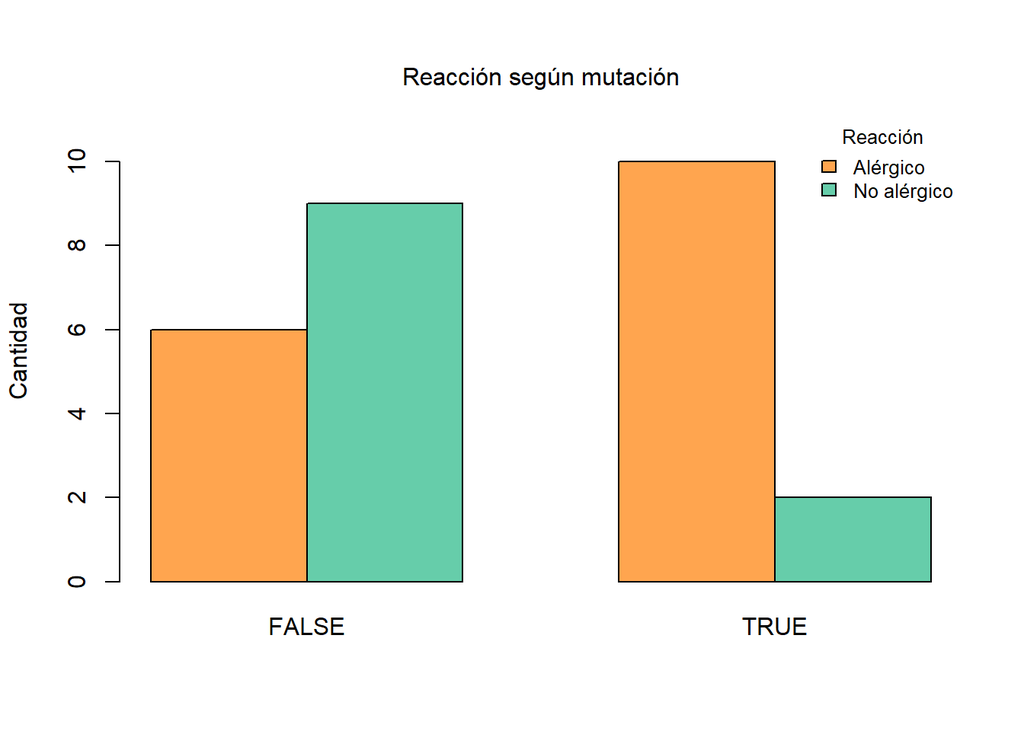

```r
par(bg="white")
barplot(TabAle,beside=TRUE,col= c("tan1","aquamarine3"),ylim=c(0,11),ylab="Cantidad")
#title("Reacción según mutación",cex=0.75)
mtext("Reacción según mutación",cex=1,line=1)
legend("topright",cex=0.8,title="Reacción",c("Alérgico","No alérgico"), fill=c("tan1","aquamarine3"),horiz=F, box.lty = 0)
```

#### Gráfico de mosaicos

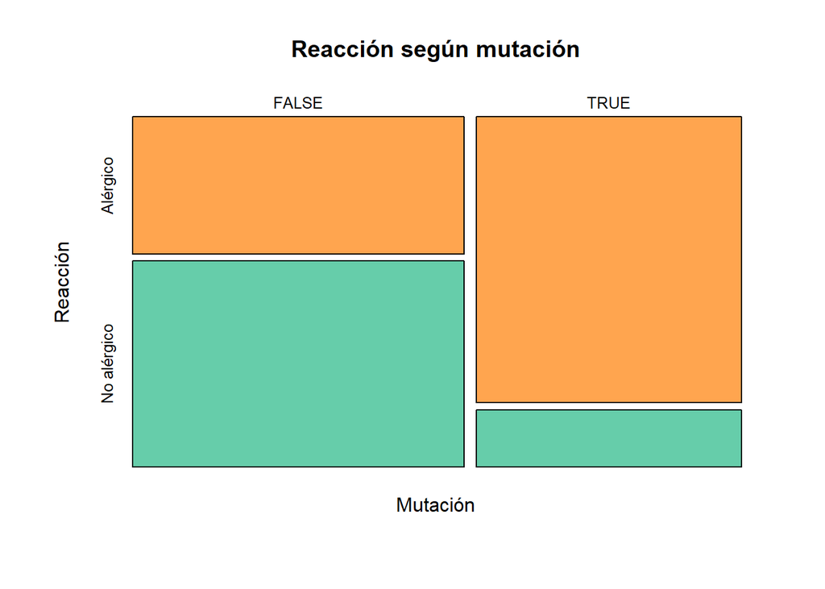

```r
mosaicplot(t(TabAle),col=c("tan1","aquamarine3"),main="Reacción según mutación",ylab="Reacción",xlab="Mutación",
           cex=0.8)
```

#### Aplicación del test exacto de Fisher:

```r
fisher.test(TabAle)
```

```
##
##  Fisher's Exact Test for Count Data
##
## data:  TabAle
## p-value = 0.04733
## alternative hypothesis: true odds ratio is not equal to 1
## 95 percent confidence interval:
##  0.01143553 1.04066993
## sample estimates:
## odds ratio
##   0.144691
```

#### Observar la respuesta que devuelve el test Chi-cuadrado…

```r
chisq.test(TabAle)
```

```
##
##  Pearson's Chi-squared test with Yates' continuity correction
##
## data:  TabAle
## X-squared = 3.5457, df = 1, p-value = 0.0597
```

# Tests de Normalidad y Homocedasticidad

## Ejemplo

Se desea analizar los datos de un experimento para estudiar el efecto del porcentaje de algodón sobre la resistencia a la tensión de una fibra sintética.

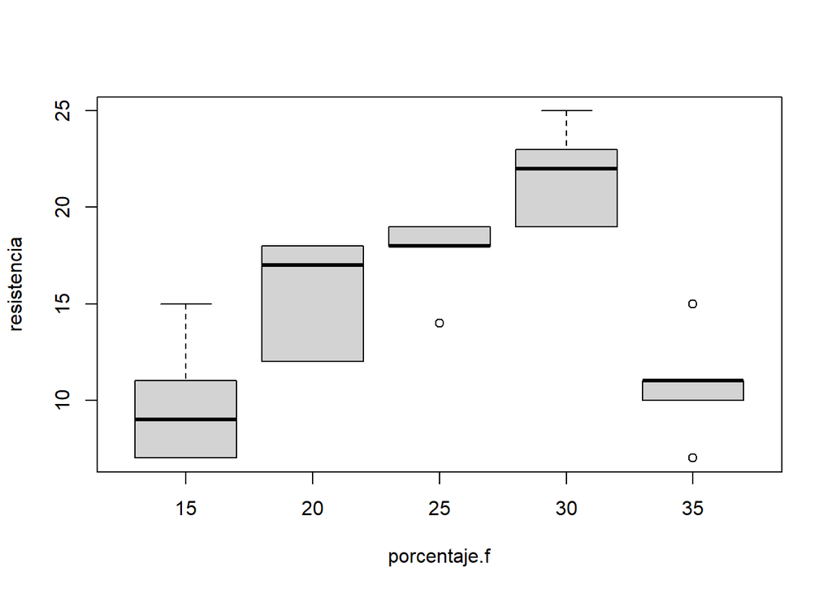

```r
porcentaje<-c(rep(15,5),rep(20,5),rep(25,5),rep(30,5),rep(35,5))
resistencia<-c(7,7,15,11,9,12,17,12,18,18,14,18,18,19,19,19,25,22,19,23,7,10,11,15,11)
porcAlgodon <-data.frame(porcentaje,resistencia)

porcentaje.f=factor(porcentaje)

plot(resistencia~porcentaje.f)# idem boxplot(resistencia~porcentaje.f)
```

### Test de homocedasticidad

#### Analizamos igualdad de varianzas:

```r
library(car)
bartlett.test(resistencia,porcentaje.f)
```

```
##
##  Bartlett test of homogeneity of variances
##
## data:  resistencia and porcentaje.f
## Bartlett's K-squared = 0.93309, df = 4, p-value = 0.9198
```

```r
leveneTest(resistencia~porcentaje.f)
```

|  | Df | F value | Pr(>F) |
| --- | --- | --- | --- |
| group | 4 | 0.3179487 | 0.8625859 |
|  | 20 | NA | NA |

### Test de normalidad

#### Analizamos normalidad:

```r
shapiro.test(resistencia)
```

```
##
##  Shapiro-Wilk normality test
##
## data:  resistencia
## W = 0.94971, p-value = 0.247
```

```r
library(nortest)
ad.test(resistencia)
```

```
##
##  Anderson-Darling normality test
##
## data:  resistencia
## A = 0.48662, p-value = 0.2052
```

```r
library(moments)
agostino.test(resistencia)
```

```
##
##  D'Agostino skewness test
##
## data:  resistencia
## skew = 0.0082619, z = 0.0201719, p-value = 0.9839
## alternative hypothesis: data have a skewness
```

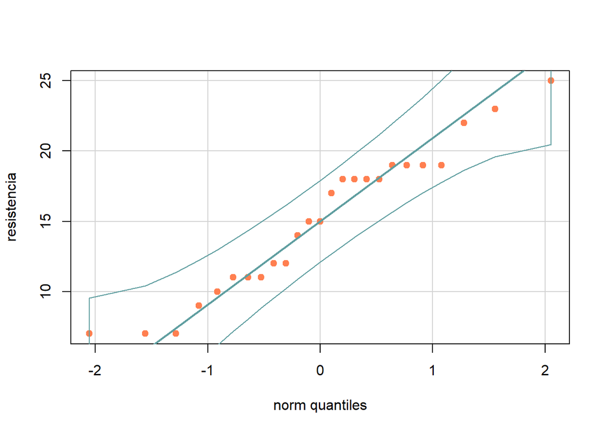

```r
qqPlot(resistencia,ylab = "resistencia", col = "coral",pch = 19, col.lines = "cadetblue",id=FALSE)
```